# Getting help

PCB 6455 / BSC 4933: Biometry | Lecture 26

Dr. Brian Maitner

## Today’s agenda

- The final project, explained
- Debugging: what to do when your code breaks
- Where to go for help, from people and from machines

Type and run on a code block: type it into your script and run it. You will need it later. Code without the label is there to watch.

## Assignment 4 is due Friday

**Friday, November 20, 11:59 pm.** Submit on Canvas.

Everything after today is the final project.

## The final project

## Three parts

| Part | Format | Builds on |
| --- | --- | --- |
| **Code** | `.R` or `.Rmd`, or a GitHub link | every assignment so far |
| **Writing** | a document | your midterm Part 1 |
| **Presentation** | about 5 minutes | the whole thing |

**Due at the presentation**, during the scheduled final exam block. Exact day and time to be confirmed.

## Part 1: the code

A **full analysis**, not a fragment:

- loading the data
- any transformations, and the reason for them
- the code behind any modeling decision you made
- the model itself
- the figures

**Fully reproducible and well documented.** Someone else should be able to run it and get your results.

## Part 2: the writing

An updated draft of your midterm writing, same three sections:

- **Introduction**: the question, and why it matters
- **Methods**: the data, and what you did to it
- **Results**: including the results of a **statistical model**, not just plots

Figures should be better than the midterm’s. You know ggplot2 now.

## Part 3: the presentation

About **five minutes**, during the final exam block.

A format that works:

- Title slide
- Background, 1 to 2 slides: what is your question, why does it matter
- Methods, 1 to 2 slides
- Results, 1 to 2 slides
- What you would do next

## Presenting well

- **Minimize text.** Roughly seven lines, seven words each, as an upper bound
- **Practice the timing**, out loud, with a clock
- **Going long costs points**, because it takes time from the next speaker

Your figures are the presentation. If a figure needs a paragraph of explanation, fix the figure.

## Any questions about the project?

## Debugging

Something you have all been doing already.

## Get set up

```r
library(tidyverse)

traits <- readRDS(url("https://tinyurl.com/amniotetraits"))

dim(traits)
```

## When something breaks

A workflow, roughly in order of effort:

1. **Re-read the code.** Most errors are typing
2. **Run it line by line** to find where it actually breaks
3. **Read the error message**, properly, all of it
4. **Search the error message**, with “R” and the package name
5. **Search a description** of what you are trying to do
6. Ask a person, with a **reprex**
7. Open an issue on the package’s GitHub
8. Read the package’s source and fix it yourself

## The usual suspects

When the error is not obvious, check these before anything else:

- **Commas, quotes and parentheses.** Especially nested ones
- **Variable names.** `adult_svl` and `adult_svl_cm` are different columns
- **`NA`s**, which propagate silently through means and sums
- **Class.** A number read in as a factor behaves nothing like a number
- **Rows against columns.** `traits[4, ]` and `traits[, 4]` are very different

## Your turn: four broken lines

Each of these is broken **on purpose**. Run them, read the errors, fix them.

```r
# all four of these are broken on purpose

# 1
traits |>
  group_by(class) |>
  summarise(mean_mass = mean(adult_body_mass_g))

# 2
data.frame(scientific_name = paste(traits[4, ], traits[5, ]))

# 3
traits |>
  group_by(class) |>
  summarise(SD_svl = sd(adult_svl_cm))

# 4
traits >
  mutate(svl_mass_ratio = adult_svl_cm / adult_body_mass_g)
```

## What was wrong

|  | Symptom | Cause |
| --- | --- | --- |
| 1 | every mean is `NA` | `adult_body_mass_g` has 4,645 `NA`s; needs `na.rm = TRUE` |
| 2 | `"Aves Aves"` | `traits[4, ]` is **row** 4, not the genus column |
| 3 | every `sd` is `NA` | same `NA` problem, not a name problem |
| 4 | `object 'adult_svl_cm' not found` | `>` is not a pipe, so `mutate()` ran with no data |

**Three of the four never raised an error.** Code that runs is not code that works, and that is the theme of the rest of today.

## Harder: errors inside loops

Debugging is harder inside `for()`, `while()` and `apply()`, because the thing that breaks is on iteration 4,417 and you cannot see it.

Techniques:

- `message()` inside the loop, to print where you are
- Set `i` by hand and run the **body** line by line
- Re-run **only the iterations that failed**
- Have the loop record what it did, not just what it produced

## A loop worth fixing

```r
# broken on purpose: run it, then work out why the answer is wrong
annual_fecundity <- NULL

for (i in 1:20) {
  species_i <- paste(traits$genus[i], traits$species[i])
  offspring_per_clutch <- traits$litter_or_clutch_size_n[i]
  clutches_per_year <- traits$litters_or_clutches_per_y[i]

  if (is.na(offspring_per_clutch) & is.na(clutches_per_year)) {
    next
  }

  out <- data.frame(species = species_i,
                    annual_offspring = offspring_per_clutch * clutches_per_year)

  annual_fecundity <- bind_rows(annual_fecundity, out)
}

annual_fecundity
```

## Asking a person

## Search well

- Include **“R”** and the **package name**
- Paste the **error message**, but strip out your own object names
- If that fails, search a **description** of the goal rather than the error

Stack Overflow is quieter than it was, and more questions now go to chatbots first. It is still the best archive of hard R problems that someone already solved.

## reprex

A **repr**oducible **ex**ample: the smallest complete thing that shows your problem.

```r
library(reprex)

reprex({
  traits <- readRDS(url("https://tinyurl.com/amniotetraits"))
  traits |>
    ggplot(mapping = aes(x = adult_body_mass_g, y = adult_svl_cm)) +
    geom_point() +
    scale_x_log10() +
    scale_y_log10()
})
```

Run it and read the output.

## What makes an example reproducible

- It includes the `library()` calls
- It includes the **data**, or a few rows of it, or a link
- It is as **small** as possible while still breaking
- It is self-contained: no objects from your session

If your example is not reproducible, people may be unkind about it. If it is reproducible, they may be unkind anyway, but you will usually get an answer.

## Asking for a favor

When you post a question or open an issue:

- **Be very nice.** You are asking a stranger to work for free
- Supply a reprex
- **Assume it is your error**, because it usually is
- Say what you already tried

For a package bug, open a **GitHub issue** on that package rather than posting to a forum. That is where the person who can fix it reads.

## AI and coding

## The landscape in 2026

It is no longer one chatbot in a browser tab. Four different things, which people all call “using AI”:

| Mode | Examples | What arrives in your project |
| --- | --- | --- |
| **Autocomplete** | Copilot in VS Code, RStudio, Positron | a few lines at a time, as you type |
| **Chat** | Claude, ChatGPT, Gemini | whatever you paste back |
| **Agent** | Claude Code, Copilot agent mode | files it edited and code it ran |
| **Review** | Copilot on a pull request | comments only, no code |

## What it is genuinely good at

- **Explaining an error message** you do not recognize
- **Translating between dialects**: base R to tidyverse and back
- **Boilerplate** you have written fifty times: themes, file loops, axis labels
- **Regular expressions**, which nobody enjoys
- Finding the **name of a function** you half-remember
- A first draft of **comments and documentation**

## What it is bad at

- **Your data.** It has never seen it and will assume it is tidy and complete
- **Statistical judgment.** It will pick a model that matches the words in your question, not the structure of your data
- **Recent changes.** Packages move; training data has a cutoff
- **Saying “I don’t know.”** It will produce something either way

Hallucinated functions still happen, especially for small ecology packages, but those are the **easy** failures: the code errors and you find out immediately.

## The failure that matters here

In a statistics course, the dangerous output is not code that breaks.

**It is code that runs, returns a plausible number, and is wrong.**

Debugging will never catch it. Nothing is broken. Only knowing the statistics catches it, which is what this whole course has been for.

## A worked example

Ask for “a test of whether bobwhite abundance declines with development” and you can very reasonably get this:

```r
bw <- read.csv("https://github.com/bmaitner/biometry_course/raw/refs/heads/main/data/class_examples/bobwhite_counts.csv")

model <- lm(count ~ frac_built, data = bw)

summary(model)
```

|  | Estimate | Std. Error | t value | Pr(>\|t\|) |
| --- | --- | --- | --- | --- |
| (Intercept) | 11.9075 | 0.3166 | 37.6107 | 0 |
| frac_built | -24.2138 | 3.1644 | -7.6521 | 0 |

Significant, negative, and it would pass any code review.

## Three checks you already know

```r
# 1. does it predict things that cannot exist?
predict(model, newdata = data.frame(frac_built = c(0, 0.5, 0.8)))

# 2. are the counts even close to normal? (Lecture 12)
var(bw$count) / mean(bw$count)

# 3. how much does it actually explain?
summary(model)$r.squared
```

| check | value |
| --- | --- |
| predicted count at 50% developed | -0.200 |
| predicted count at 80% developed | -7.460 |
| variance / mean | 10.340 |
| r squared | 0.041 |

## What it should have been

The model from Lecture 16: a negative binomial, with a mean that declines exponentially so it can never go below zero.

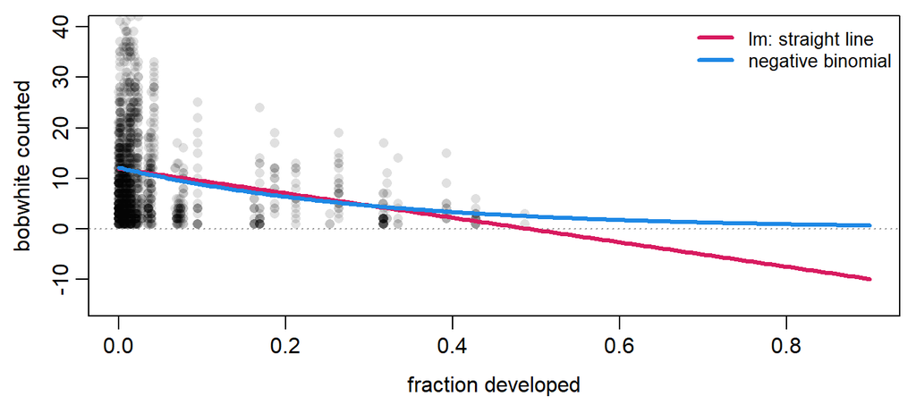

## How careful should you be?

It depends on what you are trying to learn.

**If you already know how to write it**, AI is a time saver, and you can review what it gives you because you could have written it yourself.

**If you are still learning to write it**, writing it yourself *is* the exercise. Skipping it means you will not be able to debug what you accepted, and debugging is most of the job.

**Right now, in this course, you are mostly in the second group.** That is deliberate, and it is temporary.

## What the course allows

From the syllabus, and it has not changed:

- **Code**: AI is allowed, on assignments, the midterm and the final project
- **Writing**: the text in your Part 1 and your final write-up is **yours**. No AI, no plagiarism
- **Any use must be cited**

If you are unsure whether something is permitted, ask. That is always cheaper than the alternative.

## How to cite it

Same principle as citing R and your packages. In your methods:

> Portions of the analysis code were drafted with [tool and version], then reviewed, tested and edited by the author.

And in the code itself, where it matters:

```r
# first draft of this loop from Claude, checked against a manual
# calculation for the first three species
```

Many journals now require the same disclosure. You are practicing a real norm, not a classroom one.

## Two things not to paste

- **Unpublished data** that is not yours to share, including a collaborator’s or a lab’s. A chat window is a third party
- **Anything under an agreement**: permits, embargoed data, human subjects data

Sending a few rows of a public dataset is fine. Uploading your advisor’s unpublished field data to a website is a conversation you do not want to have.

## Your turn: break something

If you use an AI tool, ask it for an analysis you already know the answer to.

Suggestions, all from this course:

- “Fit a model of bobwhite counts against year”
- “Test whether reef fish richness differs with depth”
- “Is this distribution overdispersed?”

**Then check it the way we just did.** Does it predict impossible values? Does the distribution match the data? Would you have written this?

## Take-away

1. **Read the error**, then run it line by line, then search it
2. **Code that runs is not code that works**
3. A **reprex** is how you ask a human, and it often answers itself
4. AI is good at things you can **check at a glance**, and unreliable at things that need to know your data
5. **Cite what you use**, including the tools

## Before next class

Read *R for Data Science* chapter 6: https://r4ds.hadley.nz/workflow-scripts.html

Next time: **reproducibility**, and making your project run on someone else’s machine

May be a quiz.